# Vehicle and pedestrian stops in Vermont

Our data consists of vehicle and pedestrian stops from law enforcement departments in Vermont. Using this dataset we will try to predict the outcome (whether it results in an arrest) of the traffic stop using its features.

```python
# Standard Headers
import pandas as pd
import numpy as np
import matplotlib.pyplot as plt
from sklearn.preprocessing import StandardScaler
from sklearn import preprocessing
from sklearn.model_selection import train_test_split
import seaborn as sns

import warnings
warnings.filterwarnings('ignore')
# Enable inline mode for matplotlib so that Jupyter displays graphs
%matplotlib inline
```

```python
#read the data
data = pd.read_csv('vermont.csv', header='infer')
print('Number of rows vs Number of columns')
data.shape
```

```
Number of rows vs Number of columns
```

```
(283285, 23)
```

### Data Cleaning

The dataset is missing values in many columns. We can see how many values in each column are missing.

```python
#All missing values for each column
pd.isnull(data).sum()
```

```
id                            0
state                         0
stop_date                     0
stop_time                     0
location_raw                694
county_name                 705
county_fips                 705
fine_grained_location       347
police_department             0
driver_gender              1712
driver_age_raw             1171
driver_age                 1286
driver_race_raw            3984
driver_race                4817
violation_raw              2178
violation                  2178
search_conducted              0
search_type_raw            2240
search_type              279866
contraband_found             34
stop_outcome               2325
is_arrested                   0
officer_id                   12
dtype: int64
```

The size of the dataset is big and some features are needed to build an accurate model, therefore we will delete all records with missing categorical data. For some numerical data, we will do imputation, using the mean of the column.

```python
# Location is needed to build an accurate model, so all missing data will be dropped
data = data.dropna(subset = ['county_name'])

# Driver's gender is also needed, so will drop records without gender
data = data.dropna(subset = ['driver_gender'])

# Driver's race is also needed, so will drop records without race
data = data.dropna(subset = ['driver_race'])

# Violation is also needed so will drop records without violation
data = data.dropna(subset = ['violation'])

# Search Type Raw, Contraband Found, Stop Outcome and Officer ID only include 500 records for missing values so we will drop these fields too
data = data.dropna(subset = ['search_type_raw'])
data = data.dropna(subset = ['contraband_found'])
data = data.dropna(subset = ['stop_outcome'])
data = data.dropna(subset = ['officer_id'])

# Driver's age is important but to avoid dropping further data we will fill this in with average age
data['driver_age']=data['driver_age'].astype(float) #convert data from strings to floats
mean = data['driver_age'].mean()
print("mean=", mean)
data['driver_age'].fillna(mean, inplace=True)

pd.isnull(data).sum()
```

```
mean= 38.805525581327295
```

```
id                            0
state                         0
stop_date                     0
stop_time                     0
location_raw                  0
county_name                   0
county_fips                   0
fine_grained_location       202
police_department             0
driver_gender                 0
driver_age_raw              767
driver_age                    0
driver_race_raw               0
driver_race                   0
violation_raw                 0
violation                     0
search_conducted              0
search_type_raw               0
search_type              270902
contraband_found              0
stop_outcome                  0
is_arrested                   0
officer_id                    0
dtype: int64
```

```python
data.shape
```

```
(274201, 23)
```

Columns 'is_arrested' and 'stop_outcome' contain the same data in a different form. One of those columns needs to be deleted, otherwise, we would have data leakage. Choosing 'stop_outcome' would lead to a multiclass classification; therefore we will do classification on column 'is_arrested'.

```python
pd.crosstab(data.stop_outcome, data.is_arrested, normalize='index')
#columns is_arrested and stop_outcome have the same data, one of these needs to be deleted
```

| is_arrested stop_outcome | False | True |
| --- | --- | --- |
| Arrest for Violation | 0.0 | 1.0 |
| Citation | 1.0 | 0.0 |
| Verbal Warning | 1.0 | 0.0 |
| Warrant Arrest | 0.0 | 1.0 |
| Written Warning | 1.0 | 0.0 |

From the correlation table, we see that the column that has the greatest correlation with the class label is column 'search_conducted'.

```python
data.corr()
```

|  | county_fips | driver_age_raw | driver_age | search_conducted | is_arrested | officer_id |
| --- | --- | --- | --- | --- | --- | --- |
| county_fips | 1.000000 | 0.023329 | 0.023391 | 0.000467 | -0.000168 | -0.020262 |
| driver_age_raw | 0.023329 | 1.000000 | 0.999646 | -0.075187 | -0.043471 | -0.006270 |
| driver_age | 0.023391 | 0.999646 | 1.000000 | -0.074852 | -0.043433 | -0.006253 |
| search_conducted | 0.000467 | -0.075187 | -0.074852 | 1.000000 | 0.269260 | 0.010091 |
| is_arrested | -0.000168 | -0.043471 | -0.043433 | 0.269260 | 1.000000 | 0.013594 |
| officer_id | -0.020262 | -0.006270 | -0.006253 | 0.010091 | 0.013594 | 1.000000 |

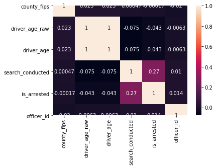

```python
sns.heatmap(data.corr(), annot=True)
```

```python
pd.crosstab(data.search_conducted, data.is_arrested, normalize='index')
```

| is_arrested search_conducted | False | True |
| --- | --- | --- |
| False | 0.991237 | 0.008763 |
| True | 0.722340 | 0.277660 |

Using the same table, we can see the relationship between the driver's race and whether they were arrested or not. It shows that a greater percentage of Black and Hispanic drivers were arrested compared to the White and Asian drivers.

```python
pd.crosstab(data.driver_race, data.is_arrested, normalize = 'index')
```

| is_arrested driver_race | False | True |
| --- | --- | --- |
| Asian | 0.993638 | 0.006362 |
| Black | 0.978354 | 0.021646 |
| Hispanic | 0.982463 | 0.017537 |
| Other | 0.973585 | 0.026415 |
| White | 0.988202 | 0.011798 |

The feature 'id' would not make sense to use as a predictive feature. As the whole dataset is made in Vermont, the column 'state' is the same in all rows. Therefore we can drop these two columns. Some columns are doubled, meaning that there is raw data that the officer wrote, and the data with values that are unified in the state. That means that the actual data (the one that is not raw) is more consistent, but the raw data has more variability. Looking at the values of these columns, we can see if raw data is more useful than the actual data, and choose which one to use for a certain feature.

```python
features_X = data.drop(['id','state','fine_grained_location','stop_date','driver_age_raw','stop_outcome','violation_raw','search_type','county_name','driver_race','officer_id', 'is_arrested'], axis = 1)
features_X.corr()

classLabel_Y = data['is_arrested']
features_X.head()
```

|  | stop_time | location_raw | county_fips | police_department | driver_gender | driver_age | driver_race_raw | violation | search_conducted | search_type_raw | contraband_found |
| --- | --- | --- | --- | --- | --- | --- | --- | --- | --- | --- | --- |
| 0 | 00:10 | East Montpelier | 50023.0 | MIDDLESEX VSP | M | 22.0 | White | Moving violation | False | No Search Conducted | False |
| 3 | 00:11 | Whiting | 50001.0 | NEW HAVEN VSP | F | 18.0 | White | Moving violation | False | No Search Conducted | False |
| 4 | 00:35 | Hardwick | 50005.0 | ROYALTON VSP | M | 18.0 | White | Moving violation | False | No Search Conducted | False |
| 5 | 00:44 | Hardwick | 50005.0 | ROYALTON VSP | F | 20.0 | White | Equipment | False | No Search Conducted | False |
| 8 | 01:10 | Rochester | 50027.0 | ROCKINGHAM VSP | M | 24.0 | Black | Moving violation | False | No Search Conducted | False |

There are features that are categorical. We need to transfer them to the numbers to be able to make models on the dataset.

```python
# label_encoder object knows how to understand word labels.
label_encoder = preprocessing.LabelEncoder()

# Keep a copy of the original features_X that we cleaned
features_X_copy = features_X.copy()

# Converting all labels to numbers
features_X['location_raw']= label_encoder.fit_transform(features_X['location_raw'])
features_X['county_fips']= label_encoder.fit_transform(features_X['county_fips'])
features_X['police_department']= label_encoder.fit_transform(features_X['police_department'])
features_X['driver_gender']= label_encoder.fit_transform(features_X['driver_gender'])
features_X['driver_race_raw']= label_encoder.fit_transform(features_X['driver_race_raw'])
features_X['violation']= label_encoder.fit_transform(features_X['violation'])
features_X['search_type_raw']= label_encoder.fit_transform(features_X['search_type_raw'])
features_X['contraband_found']= label_encoder.fit_transform(features_X['contraband_found'])
#features_X['stop_outcome']= label_encoder.fit_transform(features_X['stop_outcome'])
features_X['stop_time']= label_encoder.fit_transform(features_X['stop_time'])

#features_X['is_arrested']= label_encoder.fit_transform(features_X['is_arrested'])

features_X.head()
```

|  | stop_time | location_raw | county_fips | police_department | driver_gender | driver_age | driver_race_raw | violation | search_conducted | search_type_raw | contraband_found |
| --- | --- | --- | --- | --- | --- | --- | --- | --- | --- | --- | --- |
| 0 | 10 | 88 | 11 | 3 | 1 | 22.0 | 4 | 2 | False | 3 | 0 |
| 3 | 11 | 324 | 0 | 4 | 0 | 18.0 | 4 | 2 | False | 3 | 0 |
| 4 | 35 | 128 | 2 | 6 | 1 | 18.0 | 4 | 2 | False | 3 | 0 |
| 5 | 44 | 128 | 2 | 6 | 0 | 20.0 | 4 | 1 | False | 3 | 0 |
| 8 | 70 | 234 | 13 | 5 | 1 | 24.0 | 1 | 2 | False | 3 | 0 |

Since the dataset is imbalanced, we need to balance it. We will oversample the minority class with using Smote, and then undersample the majority class.

```python
import imblearn
from collections import Counter
from imblearn.over_sampling import SMOTE
from imblearn.over_sampling import SMOTE
from imblearn.under_sampling import RandomUnderSampler
from sklearn.svm import SVC
from sklearn.model_selection import GridSearchCV
from sklearn.model_selection import cross_val_score
from sklearn.model_selection import cross_val_predict
import sklearn as sk
from sklearn.decomposition import PCA
from sklearn.pipeline import Pipeline
#number of true/false in class label before balancing data
counter = Counter(classLabel_Y)
print(counter)
#the data needs to be balanced
#oversampeling the minority class with smote

oversample = SMOTE(sampling_strategy=0.015)
data_X, data_Y = oversample.fit_resample(features_X, classLabel_Y)
#undersampeling the majority class
under = RandomUnderSampler(sampling_strategy=0.9)
data_X, data_Y = under.fit_resample(data_X, data_Y)
#number of true/false in class label afrer balancing data
counter = Counter(data_Y)
print(counter)

data_X = pd.DataFrame(data_X)
data_Y = pd.DataFrame(data_Y)


data_X.shape
```

```
Counter({False: 270911, True: 3290})
Counter({False: 4514, True: 4063})
```

```
(8577, 11)
```

Since we have categorical variables and will be running them through SVM, Neural Nets, and KNN classifiers, we need to prepare the categorical data in the form of One Hot Encoding.

```python
# Make OneHot encoding
# use a copy of the cleaned features
OH_X = data_X.copy()
OH_Y = data_Y.copy()


# Method to perform transformation on OH_X
def get_One_Hot(columns, OH_X):
    for column_name in columns:
        OH_X = pd.concat([OH_X, pd.get_dummies(OH_X[column_name], prefix=column_name)], axis=1)
        OH_X.drop([column_name], axis=1, inplace=True)

    return OH_X

columns = ['location_raw', 'county_fips','police_department','driver_gender','driver_race_raw', 'violation','search_conducted','search_type_raw','contraband_found']

# call method
OH_X = get_One_Hot(columns, OH_X)

# scale the numeric columns
from sklearn.preprocessing import MinMaxScaler
scaler = MinMaxScaler()
OH_X['driver_age'] = scaler.fit_transform(OH_X['driver_age'].values.reshape(-1,1))
OH_X['driver_age'].value_counts()

# convert time to a numeric variable
OH_X['stop_time']= label_encoder.fit_transform(OH_X['stop_time'])
OH_X['stop_time'] = scaler.fit_transform(OH_X['driver_age'].values.reshape(-1,1))
```

### Data modeling

#### Naive Bayes

We will use the naive bayes to make a model, because the features are independent from each other.

```python
from sklearn.naive_bayes import GaussianNB
from sklearn.metrics import classification_report
#classifing with naive bayes
clf = GaussianNB()
scores = cross_val_score(clf, data_X, data_Y, cv=10)
predicts = cross_val_predict(clf, data_X, data_Y, cv=10)

print("Accuracy:", scores.mean()*100)
print(classification_report(data_Y, predicts))
```

```
Accuracy: 67.1459773210065
              precision    recall  f1-score   support

       False       0.62      0.99      0.76      4514
        True       0.96      0.32      0.48      4063

    accuracy                           0.67      8577
   macro avg       0.79      0.65      0.62      8577
weighted avg       0.78      0.67      0.63      8577
```

#### K Nearest Neighbors

For k nearest neighbors classifier we need to use scalar and pca dimensionality reduction as well as our One Hot encoding (OH_X, and OH_Y)

```python
from sklearn.neighbors import KNeighborsClassifier
from sklearn.tree import DecisionTreeClassifier


scaler = sk.preprocessing.MinMaxScaler()
pca = PCA()
knn = KNeighborsClassifier()

pipe = Pipeline(steps=[('scaler', scaler), ('pca', pca), ('knn', knn)])

param_grid = {
    'pca__n_components': list(range(1, 11)),
    'knn__n_neighbors': list(range(1, 10)),
}

grid_search = GridSearchCV( pipe, param_grid, cv=5, scoring='accuracy')
grid_search.fit(OH_X, OH_Y)

print(grid_search.best_params_)

nested_score = cross_val_score(grid_search, OH_X, OH_Y, cv=5)
print("Accuracy:", nested_score.mean()*100)


predicts = cross_val_predict(grid_search, OH_X, OH_Y, cv=5)
print(classification_report(OH_Y, predicts))
```

```
{'knn__n_neighbors': 8, 'pca__n_components': 4}
Accuracy: 71.02695943512269
              precision    recall  f1-score   support

       False       0.69      0.82      0.75      4514
        True       0.75      0.59      0.66      4063

    accuracy                           0.71      8577
   macro avg       0.72      0.71      0.71      8577
weighted avg       0.72      0.71      0.71      8577
```

#### Neural Networks

We will need to use our One Hot encoded data for Neural Nets (OH_X and OH_Y)

```python
from sklearn.neural_network import MLPClassifier


scaler = sk.preprocessing.MinMaxScaler()
clf = MLPClassifier()

pipe =  Pipeline(steps=[('scaler', scaler), ('MLP', clf)])

param_grid = {'MLP__hidden_layer_sizes': [(10,), (20,), (30,), (40,), (50,)],
             'MLP__activation' : ['identity', 'logistic', 'tanh', 'relu']}

grid_search = GridSearchCV(pipe, param_grid, cv=3, scoring='accuracy')
grid_search.fit(OH_X, OH_Y)
print(grid_search.best_params_)
nested_score = cross_val_score(grid_search, OH_X, OH_Y, cv=3)

print("Accuracy:", nested_score.mean()*100)

predicts = cross_val_predict(grid_search, OH_X, OH_Y, cv=3)
print(classification_report(OH_Y, predicts))
```

```
{'MLP__activation': 'logistic', 'MLP__hidden_layer_sizes': (10,)}
Accuracy: 72.49621079631574
              precision    recall  f1-score   support

       False       0.70      0.85      0.76      4514
        True       0.78      0.59      0.67      4063

    accuracy                           0.73      8577
   macro avg       0.74      0.72      0.72      8577
weighted avg       0.73      0.73      0.72      8577
```

#### Support Vector Machines

For support vector machines we need to use scalar and pca dimensionality reduction.

```python
from sklearn.svm import SVC
from sklearn.pipeline import Pipeline
#scaler = sk.preprocessing.MinMaxScaler()
from sklearn.decomposition import PCA

clf = SVC()
pca = PCA()

# Data for OneHot encoding is already scaled and in sparse matrix
pipe =  Pipeline([('PCA',pca),('SVM', clf)])

param_grid = {'PCA__n_components':list(range(1,11)),
    'SVM__kernel': ['linear', 'rbf', 'poly', 'sigmoid']}

grid_search = GridSearchCV(pipe, param_grid, cv=3, scoring='accuracy')
grid_search.fit(OH_X, OH_Y)
print(grid_search.best_params_)

nested_score = cross_val_score(grid_search, OH_X, OH_Y, cv=3)
print("Accuracy:", nested_score.mean()*100)
predicts = cross_val_predict(grid_search, OH_X, OH_Y, cv=3)
print(classification_report(OH_Y, predicts))
```

```
{'PCA__n_components': 10, 'SVM__kernel': 'rbf'}
Accuracy: 72.39127900198204
              precision    recall  f1-score   support

       False       0.68      0.91      0.78      4514
        True       0.84      0.52      0.64      4063

    accuracy                           0.72      8577
   macro avg       0.76      0.71      0.71      8577
weighted avg       0.75      0.72      0.71      8577
```

#### Ensemble Classifiers

```python
from sklearn.ensemble import AdaBoostClassifier

clf = AdaBoostClassifier()

par = {"n_estimators": range(10,200,20) }

grid_search = GridSearchCV(clf, par, cv=5, scoring='accuracy')
grid_search.fit(data_X, data_Y)

print(grid_search.best_params_)
nested_score = cross_val_score(grid_search, data_X, data_Y, cv=5)

print("Accuracy:", nested_score.mean()*100)
predicts = cross_val_predict(grid_search, data_X, data_Y, cv=5)
print(classification_report(data_Y, predicts))
```

```
{'n_estimators': 90}
Accuracy: 74.43152086009228
              precision    recall  f1-score   support

       False       0.72      0.84      0.78      4514
        True       0.79      0.63      0.70      4063

    accuracy                           0.74      8577
   macro avg       0.75      0.74      0.74      8577
weighted avg       0.75      0.74      0.74      8577
```

```python
from sklearn.ensemble import RandomForestClassifier

clf = RandomForestClassifier()


par = {"max_depth": range(30,45) ,
      "min_samples_leaf": [9,12,15,18],
       "max_features" : ['sqrt', 'log2']}

grid_search = GridSearchCV(clf, par, cv=5, scoring='accuracy')
grid_search.fit(data_X, data_Y)

print(grid_search.best_params_)
nested_score = cross_val_score(grid_search, data_X, data_Y, cv=5)

print("Accuracy:", nested_score.mean()*100)
predicts = cross_val_predict(grid_search, data_X, data_Y, cv=5)
print(classification_report(data_Y, predicts))
```

```
{'max_depth': 30, 'max_features': 'log2', 'min_samples_leaf': 9}
Accuracy: 75.44593501736358
              precision    recall  f1-score   support

       False       0.73      0.85      0.78      4514
        True       0.79      0.65      0.71      4063

    accuracy                           0.75      8577
   macro avg       0.76      0.75      0.75      8577
weighted avg       0.76      0.75      0.75      8577
```

# Conclusion

To model our data we used the following classifiers with their respective accuracies:

- Naive Bayes: 67.146
- K Nearest Neightbors: 71.027
- Neural Network: 72.496
- Support Vector Machines: 72.391
- Ensemble Classifier using AdaBoost: 74.432
- Random Forest: 75.446